# hw5_Lin

Keven Lin

11/06/2021

# Liquor Sales in Iowa

This dataset https://data.iowa.gov/Sales-Distribution/2021-Iowa-Liquor-Sales/cc6f-sgik contains the spirits purchase information of Iowa Class “E” liquor licensees by product and date of purchase for 2021. The dataset contains the orders of the liquors by retailer, e.g. Hyvee.

## 1. Download data set

```r
library(readxl)
library(tidyverse)
```

```r
library(ggplot2)
library(ggthemes)
library("lobstr")
library(dplyr)
library(purrr)
library(stringr)
library(strex)
liquorSale <- read.csv('2021_Iowa_Liquor_Sales.csv')
#head(liquorSale)
```

## 2. Data Cleaning

1. Convert the Date column into a date object

```r
liquorSale$Date = as.Date(liquorSale$Date, '%m/%d/%Y')
str(liquorSale)
```

```
## 'data.frame':    2145006 obs. of  24 variables:
##  $ Invoice.Item.Number  : chr  "INV-33202600018" "INV-33190700004" "INV-33169600155" "INV-33174300034" ...
##  $ Date                 : Date, format: "2021-01-04" "2021-01-04" ...
##  $ Store.Number         : int  5336 5650 2528 5347 4070 2561 2552 3842 4184 2567 ...
##  $ Store.Name           : chr  "Express Mart" "The Depot Williamsburg" "Hy-Vee Food Store #3 / Des Moines" "Kum & Go #1097 / 50th WDM" ...
##  $ Address              : chr  "4804 S Highway 61" "103 Highland St" "3221 SE 14th St" "220 50th St" ...
##  $ City                 : chr  "Muscatine" "Williamsburg" "Des Moines" "West Des Moines" ...
##  $ Zip.Code             : int  52761 52361 50315 50265 52208 50321 52404 50517 52761 52806 ...
##  $ Store.Location       : chr  "" "" "" "POINT (-93.770919 41.572085)" ...
##  $ County.Number        : int  70 48 77 77 6 77 57 55 70 82 ...
##  $ County               : chr  "MUSCATINE" "IOWA" "POLK" "POLK" ...
##  $ Category             : int  1081200 1012100 1022200 1012100 1051100 1031100 1701100 1081600 1071100 1062400 ...
##  $ Category.Name        : chr  "Cream Liqueurs" "Canadian Whiskies" "100% Agave Tequila" "Canadian Whiskies" ...
##  $ Vendor.Number        : int  305 260 255 259 434 273 65 421 395 259 ...
##  $ Vendor.Name          : chr  "Mhw LTD" "DIAGEO AMERICAS" "Infinium Spirits" "Heaven Hill Brands" ...
##  $ Item.Number          : int  73055 10803 89242 11771 54448 37040 16906 86887 58860 43026 ...
##  $ Item.Description     : chr  "Rumchata" "Crown Royal Regal Apple Mini" "Corralejo Reposado" "Black Velvet Mini" ...
##  $ Pack                 : int  12 10 6 8 6 6 6 12 6 12 ...
##  $ Bottle.Volume..ml.   : int  750 50 750 50 1750 750 750 1000 1750 750 ...
##  $ State.Bottle.Cost    : num  13.5 7.35 16 8.5 11.29 ...
##  $ State.Bottle.Retail  : num  20.2 11 24 12.8 16.9 ...
##  $ Bottles.Sold         : int  3 4 6 3 3 6 1 12 6 12 ...
##  $ Sale..Dollars.       : num  60.8 44.1 144 38.2 50.8 ...
##  $ Volume.Sold..Liters. : num  2.25 0.2 4.5 0.15 5.25 4.5 0.75 12 10.5 9 ...
##  $ Volume.Sold..Gallons.: num  0.59 0.05 1.18 0.03 1.38 1.18 0.19 3.17 2.77 2.37 ...
```

2. Extract the longitude and latitude from the Store Location column, creating two new columns

```r
# remove all non numeric values from
temp = gsub("[A-Z]", '', liquorSale$Store.Location)

# remove all ()
temp = gsub("[()]", '', temp)

#remove extra white space
temp = gsub("\\s+"," ",temp)
temp = trimws(temp)

#replace space with comma
temp = str_replace(temp, ' ', ',')
liquorSale$temp = temp
```

```r
#liquorSale
liquorSale = liquorSale %>% separate(temp, c("longitude", "latitude"), sep = ',')
#liquorSale
```

```r
liquorSale$longitude = as.numeric(liquorSale$longitude)
liquorSale$latitude = as.numeric(liquorSale$latitude)
str(liquorSale)
```

```
## 'data.frame':    2145006 obs. of  26 variables:
##  $ Invoice.Item.Number  : chr  "INV-33202600018" "INV-33190700004" "INV-33169600155" "INV-33174300034" ...
##  $ Date                 : Date, format: "2021-01-04" "2021-01-04" ...
##  $ Store.Number         : int  5336 5650 2528 5347 4070 2561 2552 3842 4184 2567 ...
##  $ Store.Name           : chr  "Express Mart" "The Depot Williamsburg" "Hy-Vee Food Store #3 / Des Moines" "Kum & Go #1097 / 50th WDM" ...
##  $ Address              : chr  "4804 S Highway 61" "103 Highland St" "3221 SE 14th St" "220 50th St" ...
##  $ City                 : chr  "Muscatine" "Williamsburg" "Des Moines" "West Des Moines" ...
##  $ Zip.Code             : int  52761 52361 50315 50265 52208 50321 52404 50517 52761 52806 ...
##  $ Store.Location       : chr  "" "" "" "POINT (-93.770919 41.572085)" ...
##  $ County.Number        : int  70 48 77 77 6 77 57 55 70 82 ...
##  $ County               : chr  "MUSCATINE" "IOWA" "POLK" "POLK" ...
##  $ Category             : int  1081200 1012100 1022200 1012100 1051100 1031100 1701100 1081600 1071100 1062400 ...
##  $ Category.Name        : chr  "Cream Liqueurs" "Canadian Whiskies" "100% Agave Tequila" "Canadian Whiskies" ...
##  $ Vendor.Number        : int  305 260 255 259 434 273 65 421 395 259 ...
##  $ Vendor.Name          : chr  "Mhw LTD" "DIAGEO AMERICAS" "Infinium Spirits" "Heaven Hill Brands" ...
##  $ Item.Number          : int  73055 10803 89242 11771 54448 37040 16906 86887 58860 43026 ...
##  $ Item.Description     : chr  "Rumchata" "Crown Royal Regal Apple Mini" "Corralejo Reposado" "Black Velvet Mini" ...
##  $ Pack                 : int  12 10 6 8 6 6 6 12 6 12 ...
##  $ Bottle.Volume..ml.   : int  750 50 750 50 1750 750 750 1000 1750 750 ...
##  $ State.Bottle.Cost    : num  13.5 7.35 16 8.5 11.29 ...
##  $ State.Bottle.Retail  : num  20.2 11 24 12.8 16.9 ...
##  $ Bottles.Sold         : int  3 4 6 3 3 6 1 12 6 12 ...
##  $ Sale..Dollars.       : num  60.8 44.1 144 38.2 50.8 ...
##  $ Volume.Sold..Liters. : num  2.25 0.2 4.5 0.15 5.25 4.5 0.75 12 10.5 9 ...
##  $ Volume.Sold..Gallons.: num  0.59 0.05 1.18 0.03 1.38 1.18 0.19 3.17 2.77 2.37 ...
##  $ longitude            : num  NA NA NA -93.8 -92.3 ...
##  $ latitude             : num  NA NA NA 41.6 41.9 ...
```

3. (Optional) You may want to rename a few columns for your convenience. —– Don’t need to ——

## 3. First overview: Provide a visual breakdown of the liquor category (by Category Name). Include volume sold in the breakdown. Describe your figure. Which type of liquor is the most popular?

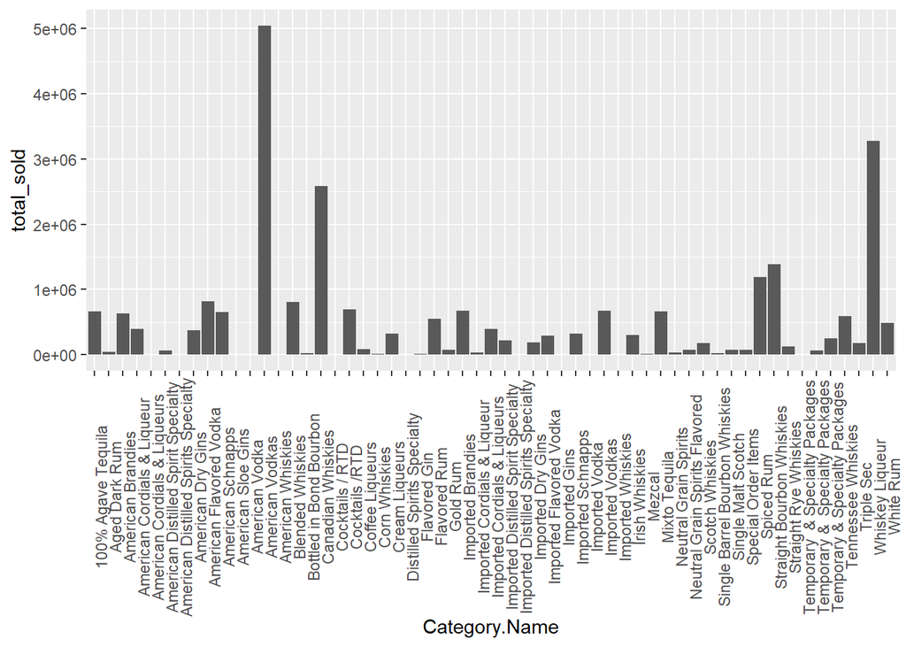

```r
options(repr.plot.width=100, repr.plot.height=100)
liquorSale %>% group_by(Category.Name) %>% summarise(total_sold = sum(Bottles.Sold)) %>% ggplot(aes(x=Category.Name, y = total_sold)) + geom_bar(stat="identity") + theme(axis.text.x = element_text(angle = 90))
```

According to the graph, American Vodka is the most popular liquor.

## 4. Which day of the week has the most orders? Use a barchart to visualize the results. Explain the pattern and provide a reason why the pattern occurs.

```r
liquorSale$Day = weekdays(liquorSale$Date)
```

```r
#liquorSale
```

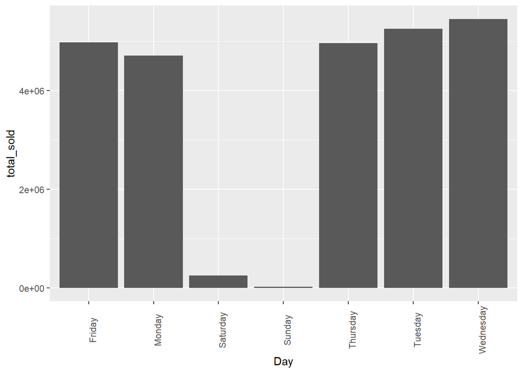

```r
liquorSale %>% group_by(Day) %>% summarise(total_sold = sum(Bottles.Sold)) %>% ggplot(aes(x=Day, y = total_sold)) + geom_bar(stat="identity") + theme(axis.text.x = element_text(angle = 90))
```

So based on the data, we can see that nearly all of the orders are made during the weekday and almost none are made on the weekend. This does make sense as most supplies in the US typically do not process orders on the weekend unless is an urgent circumstance.

## 5. Create a single plot for the monthly volumes sold. Each liquor category should be shown using a separate time series. Label the top 5 categories using text labels.

```r
liquorSale$Month = format(liquorSale$Date, '%m')
```

```r
top5 = liquorSale %>% group_by(Category.Name) %>% summarise(total = sum(Bottles.Sold)) %>% arrange(-total) %>% select(Category.Name) %>% head(5)
top5
```

```
## # A tibble: 5 x 1
##   Category.Name
##   <chr>
## 1 American Vodkas
## 2 Whiskey Liqueur
## 3 Canadian Whiskies
## 4 Straight Bourbon Whiskies
## 5 Spiced Rum
```

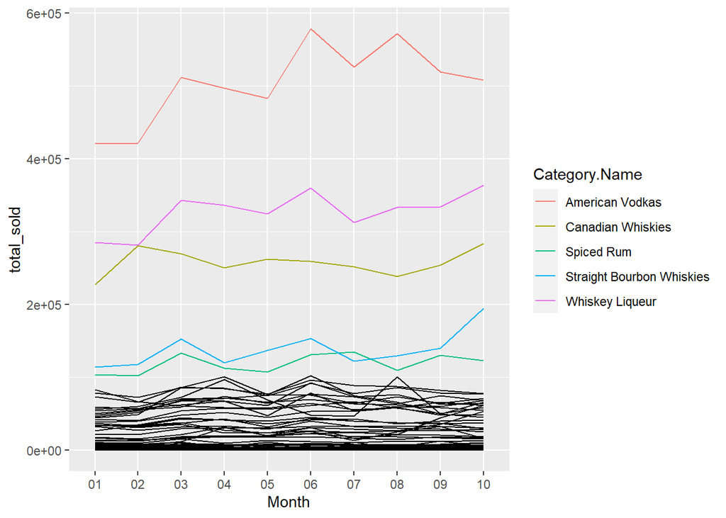

```r
filterdata = liquorSale %>% filter(!Category.Name %in% t(top5))


top5 = liquorSale %>% filter(Category.Name %in% t(top5))


filterdata %>%
  group_by(Category.Name, Month) %>% summarise(total_sold = sum(Bottles.Sold)) %>%
  ggplot() +
  geom_line(data = top5 %>% group_by(Category.Name, Month) %>% summarise(total_sold = sum(Bottles.Sold)), aes(group=Category.Name, x=Month, y = total_sold, color=Category.Name)) +
  geom_line(aes(group=Category.Name, x=Month, y = total_sold),  stat="identity")
```

## 6. Which categories are spring graduation party favorites? Find at least one category.

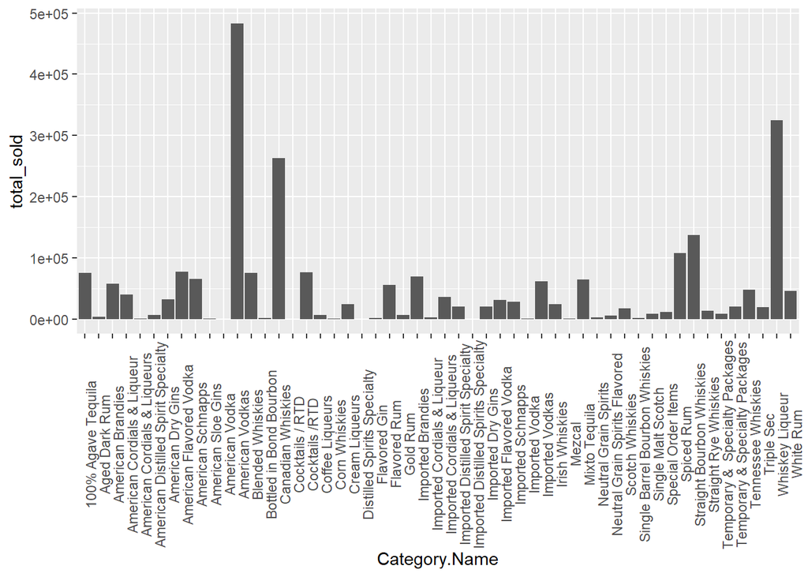

```r
liquorSale$Month = months(liquorSale$Date)
liquorSale %>% group_by(Category.Name) %>% filter(Month %in% c('May')) %>% summarise(total_sold = sum(Bottles.Sold)) %>% ggplot(aes(x=Category.Name, y = total_sold)) + geom_bar(stat="identity") + theme(axis.text.x = element_text(angle = 90))
```

From the graph, we can see that American Vodka is the most popular spring graduation drink.

## 7. (Optional) We would like to compare the liquor orders in each month. Create a complex time series plot of the volume sold in each day. Each month should be shown in a separate panel. Label the day of the week for the x-axis tick labels. Which months have more orders than the others?

[Hint: Each panel should show a time series, where the x-axis stands for date, and y-axis stands for the volume sold. The tick labels of the x-axis, however, should show the day of week but not date. E.g., if the x-axis data were Jan 01, 2021 and Jan 10, 2021, then the re-labeled ticks should show Friday and Sunday for these two dates instead.]